# Capital, Labour and Justice

Lecture 3: Technology, AI and work

Dr David Chivers

Political Economy

## Technology and jobs

[figure not shown]

## Technology & Labour

- There has always been concern that technology would eventually replace jobs
- John Maynard Keynes warned of “technological unemployment”
- Wassily Leontief suggested “labour will become less and less important.“
- During the 20<sup>th</sup> century of unprecedented technological advancement in transportation, production, and communication, labour’s share of national income remained roughly constant (Kaldor, 1961)
- However, during the 21<sup>st</sup> century, labour’s share of income has fallen in many nations (Gutiérrez and Philippon, 2017)

## Automation and Labour

[figure not shown]

## Technological & Labour

- There are two direct effects that a new technology can have on labour:
- **Labour Augmenting:** A new technology makes workers more productive and increases demand for labour
- **Labour Displacing**: A new technology replaces the need for workers and capital takes over, decreasing the demand for labour
- There are also indirect effects
- **Compensation effects:** due to increases in productivity we see an increase in demand for labour from other industries
- The net impact of automation on labour demand thus depends on how the displacement and productivity effects weigh against each other.

## Production

- The Constant Elasticity of Substitution (CES) production function is given as follows:

$$Y\ = \ {\lbrack{{(A}^{k}K)}^{\rho} + {{(A}^{L}L)}^{\rho}\rbrack\ }^{\frac{1}{\rho}}$$

- Production $Y$ is produced by capital $K$ and labour $L$
- $A^{k}$ & $A^{L}$ are **factor-augmenting technologies** associated with capital and labour, respectively
- $\rho$ is the elasticity of substitution

## Technology & Production

- Let’s say there was new technology that augmented capital, $A^{k}$, how does this affect labour?

$$Y\ = \ {\lbrack{{(A}^{k}K)}^{\rho} + {{(A}^{L}L)}^{\rho}\rbrack\ }^{\frac{1}{\rho}}$$

- If $\rho > 0$ capital and labour are gross substitutes
- If $\rho < 0$ capital and labour are gross complements
- If $\rho = 0$ you get a traditional Cobb–Douglas with fixed shares to labour and capital
- Oberfield and Raval’s (2014) suggest $\rho = 0.8$
- When markets are competitive, the price of each factor is its marginal product
- The rental rate of capital is $r$ and the wage rate of labour is $w$

## Technology & Production

- Dividing the marginal products of each capital and labour gives us the relative prices. Assume $\rho > 0$

$$\frac{r}{w}\ = \left( \frac{{\ A}^{k}}{{\ A}^{L}} \right)^{\rho}\left( \frac{K}{L} \right)^{- (1 - \rho)}$$

## Will robots take our jobs?

## Will robots take our jobs?

[figure not shown]

## Will robots take our jobs?

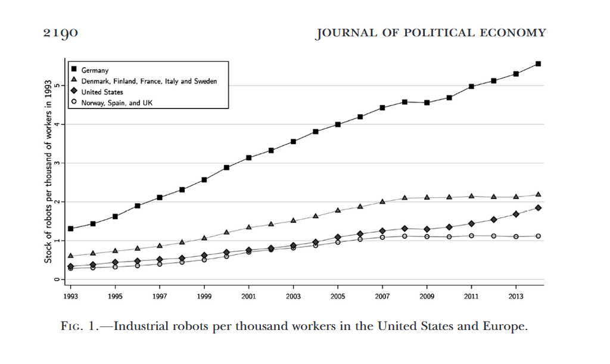

## Technology & Tasks

- Automation, via robots, directly displaces an individual job or task
- **Productivity effect:** By allowing a more flexible allocation, automation contributes to the demand for labour in non-automated tasks
- The introduction of ATMs (cash machines) increased employment of bank tellers
- This reduced cost of banking and increased branches where bank tellers specialised in tasks that ATMs could not do (Bessen, 2016)
- **Reinstatement effect**—labour can be reinstated to a broader range of tasks
- For example, although software and computers have replaced labour in white-collar tasks, they have simultaneously created many new tasks
- Employment growth over 1980–2015 took place in occupations in which job titles or tasks performed by workers changed (Acemoglu and Restrepo, 2018)

## Automation & Tasks

- Production requires the completion of a range of tasks. Let’s take the process of making a shirt:
- Production tasks: extraction of fibres, spinning to produce yarn, weaving, knitting, dyeing, and processing
- Non-production tasks: accounting, marketing, transportation, and sales
- The canonical model imposes that all technology changes are factor augmenting (i.e. a rise in $A^{k}$ or $A^{L}$)

$$Y\ = \ {\lbrack{{(A}^{k}K)}^{\rho} + {{(A}^{L}L)}^{\rho}\rbrack\ }^{\frac{1}{\rho}}$$

- However, a rise in robots for example, does not make capital or labour more productive
- Robots instead expand the set of tasks that can be produced by capital.

## Comparing Effects on Labour Demand

- Effect of **Factor-Augmenting Technologies** on labour demand = **Productivity effect** + **Substitution effect**
- Effect of **New Tasks** on labour demand = **Productivity effect** + **Reinstatement effect**
- Effect of **Automation** on labour demand = **Productivity effect** + **Displacement effect.**
- It is incorrect to presume that all technologies increase labour demand as displacement effects may be larger than productivity gains
- Suggestion: we need to be wary of “so-so” technologies e.g. self-check outs (Acemoglu and Restrepo, 2018)

## Technology & Tasks

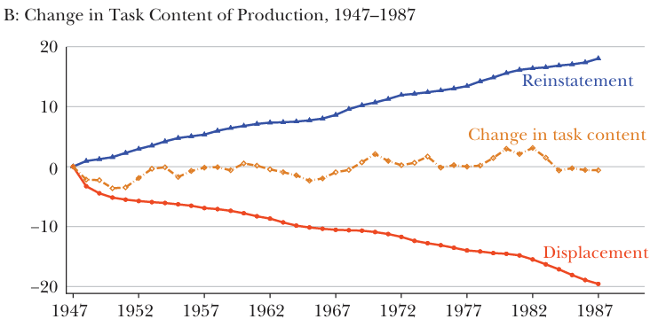

## Technology & Tasks

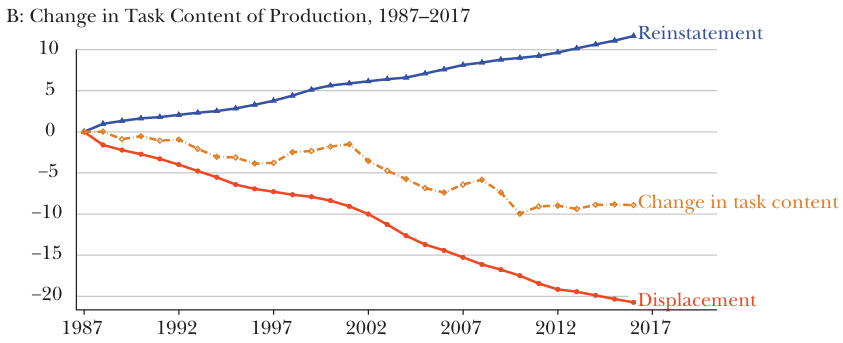

## AI and Jobs

- The effects of AI as a technology is more uncertain than robots
- AI may cause a growth in new tasks. But like automation, it might cause displacement effects
- How quickly AI develops will be critical in how it affects the economy
- This is because the reallocation of labour from existing jobs to new ones is a slow process
- Although the Industrial Revolution ultimately led to rising wages in Britain, this only happened after a protracted period of poverty and harsh living conditions
- **The “Engels’ pause”:** for the first 80 years after the start of the industrial revolution, the labour share fell, even as technological advances and productivity growth were growing (Allen, 2009)
- AI may differ to robots: AI may replace more complex tasks associated with innovation and creativity, whereas robots has traditionally replaced routine (boring) tasks.

## Technology and Inequality

- Automation may increase inequality as it tends to benefit capital over labour
- For low and medium skilled workers, automation has reduced wages (Van Reenen, 2014)
- Wages decline in areas most exposed to one specific type of automation, the introduction of industrial robots in manufacturing (Acemoglu and Restrepo, 2017)
- Alternatively, AI may reduce inequality by making expertise available to non-elites (Autor, 2024)
- What would prevent a Sci-fi dystopia where the displacement effect completely dominates?
- One proposed solution is a [sovereign wealth fund](https://www.peoplespolicyproject.org/projects/social-wealth-fund/), a state-owned investment fund
- This would act as an insurance against the labour share of income falling
- Another solution involves going back in time and [Arnold Schwarzenegger](https://www.youtube.com/watch?v=CRRlbK5w8AE).

## Summary

- There have always been predictions that technology will replace jobs
- Traditionally, new technologies have not resulted in a decreasing labour share of income
- Recently the labour share has been declining, partly as a result of automation
- The effects of Robots or AI on jobs depends on productivity vs displacement effects
- See [Talis](https://durham.rl.talis.com/modules/econ2301.html) for **reading list**.

Note: not all citations in this lecture are listed there.